This whole post is available as an IPython Notebook [here](http://nbviewer.ipython.org/github/mglerner/MarchMadnessMonteCarlo/blob/master/MMMC2015.ipynb).

# MMMC the 2015 update

See the [original blog post](http://www.mglerner.com/blog/?p=16) for details and history. Here's the short story: in my Statistical and Thermal Physics class, we want to use Monte Carlo simulations to generate brackets for March Madness. There are at least two obvious ways to go about this:

1. Make some function that tells us the chance that team A beats team B, then flip coins for each matchup. That gets you one bracket. Repeat 100,000 times, collect statistics. This is the way Nate Silver's 538.com handles simulations for [basketball](http://fivethirtyeight.com/interactives/march-madness-predictions-2015/#mens), [elections](http://fivethirtyeight.com/interactives/senate-forecast/), etc, and I should probably implement it (note to self/motivated students: it's as easy as just generating 100,000 new brackets at a given temperature).
2. Generate one bracket, then do a Monte-Carlo walk through bracket space. This is tougher. We have to figure out how to make a move in bracket space, which is part of the fun of Monte Carlo simulations in general. To see how this is done, check out the code in `Bracket.swap` and `Brackets.simulate`.

As you can tell, we take option 2 above. I've made things a bit nicer from a user standpoint this year; here's a walkthrough. First, load up our standard IPython setup

```python
from __future__ import division
%matplotlib inline
import seaborn as sns
sns.set_style('darkgrid')
import numpy as np
from matplotlib import pyplot as plt
from IPython.display import HTML
```

## The basics

make me a single bracket at a given temperature

```python
import MarchMadnessMonteCarlo as MMMC
teams = MMMC.teams['south']
b = MMMC.Bracket(teams=teams,T=0.5)
print b
```

```
Duke (1)
Robert Morris (16)        Duk (1)
San Diego St. (8)
St. John's (9)            San (8)  Duk (1)
Utah (5)
Stephen F. Austin (12)    Ste (12)
Georgetown (4)
Eastern Washington (13)   Geo (4)  Ste (12) Ste (12)
SMU (6)                   UCL (11) UCL (11) UCL (11) Ste (12)
UCLA (11)
Iowa St. (3)              Iow (3)
UAB (14)
Iowa (7)                  Iow (7)  Iow (7)
Davidson (10)
Gonzaga (2)               Gon (2)
North Dakota St. (15)
Total bracket energy: -17.4533174222
```

Now, instead of asking for all of the teams in the South, make up a set of Final Four teams, and run 1000 simulations. Show some statistics

```
Lowest energy bracket
Kentucky (1)
Wisconsin (1)             Ken (1)
Villanova (1)             Vil (1)  Ken (1)
Duke (1)
Total bracket energy: -3.05919025906

Most common bracket (159)
Kentucky (1)
Wisconsin (1)             Ken (1)
Villanova (1)             Duk (1)  Ken (1)
Duke (1)
Total bracket energy: -3.04122415391
```

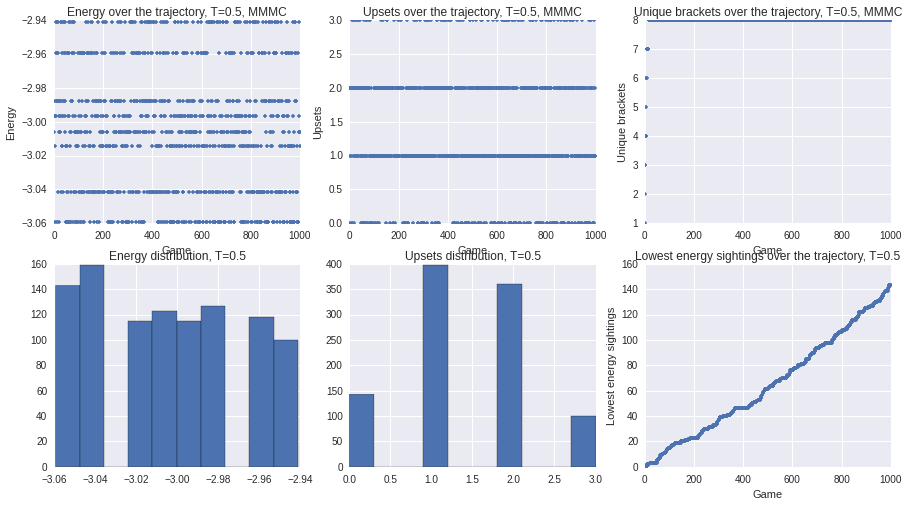

```python
sr = MMMC.simulate(1000,['Kentucky','Wisconsin','Villanova','Duke'],0.5)
MMMC.showstats(sr,newfig=True)
```

As you can see, we fully sample bracket space pretty quickly (look at the graph in the top right, with the unique brackets shown).

# What should our temperature be?

If we had chosen option 1 at the top, we'd just flip coins with a given probability of winning. Here (and this may be a questionable decision), we need to set an overall temperature for our simulation. Intuitively, the higher the temperature, the closer we come to a random outcome. The lower the temperature, the closer we come to a "best seed always wins" bracket. If we're going to make sense of temperature, we should pick a reasonable energy function.

We can use [KenPom](http://www.kenpom.com)'s `log5` defined as

```
def log5_energy_game(winner, loser):
    A,B = strength[winner],strength[loser]
    # see http://207.56.97.150/articles/playoff2002.htm
    win_pct = (A-A*B)/(A+B-2*A*B)
    return -win_pct
```

Conveniently, that's coded up for you in MarchMadnessMonteCarlo.examples.

Later on, we could make a fancy energy function with, e.g., a weighted average of KenPom, Jeff Sagarin, and the NCAA rankings.

```python
import MarchMadnessMonteCarlo.examples
MMMC.set_energy_function(MarchMadnessMonteCarlo.examples.log5_energy_game)
```

Now, what should our actual temperature be? Historically, we know that an 8 seed vs. a 9 seed should essentially be a tossup. So, as a proxy here, we could just look at the chance of an 8 seed winning over a range of temperatures, and pick the point where it's pretty close to 0.5.

```python
def winpct8(team8,team9,T,numtrials=10000):
    results = [MMMC.playgame(team8,team9,T)[0] == team8 for i in range(numtrials)]
    return np.average(results)
def plotwins(team8,team9,numtrials=10000):
    Ts = np.linspace(0,3,100)
    pct = [winpct8(team8,team9,T,numtrials) for T in Ts]
    plt.plot(Ts,pct,label='{t1} vs. {t2}'.format(t1=team8,t2=team9))
    plt.xlabel('T')
    plt.ylabel('winpct')
```

We'll look at it for all four of the 8 vs. 9 matchups

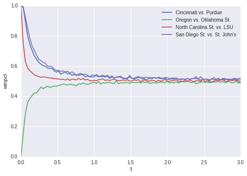

```python
plotwins('Cincinnati','Purdue')
plotwins('Oregon','Oklahoma St.')
plotwins('North Carolina St.','LSU')
plotwins('San Diego St.',"St. John's")
plt.legend()
```

A couple of things jump out. First, the green line: KenPom has Oregon ranked below Oklahoma State, so the curve approaches 50% from below instead of from above.

Second, just eyeballing that, it looks like we could make a legitimate argument for almost anything between T=1.0 and 2.0.

What does that do to "clear" matchups? Well, Kentucky is a big favorite over Kansas with this model:

```python
MarchMadnessMonteCarlo.examples.log5_energy_game('Kentucky','Kansas')
```

```
-0.8176307825952608
```

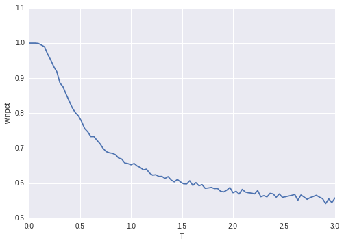

```python
plotwins('Kentucky','Kansas')
```

If I pick `T=1.5`, I get Kentucky, the favorite, winning 60% of the time. You can feel free to choose a "saner" temperature, but I'm rooting for KU here!

## Running some brackets!

So what does a bracket happen to look like? Well, in the original blog post, I mentioned that we came up with two different ways to run brackets. It can take a while to run a bracket, so a fast way (implemented as `runbracket2`) is to run separate brackets for each of the individual regions, then take the winner from each region's most common bracket to form a Final Four. Below, we do just that, running 10,000 trials for each of the regions, and 1000 trials for the Final Four.

```python
results = MMMC.runbracket2(ntrials1=10000,ntrials2=1000,T=1.5)
```

```
YOUR LOWEST ENERGY BRACKETS
LOWEST ENERGY BRACKET FOR REGION midwest
Kentucky (1)
Hampton (16)              Ken (1)
Cincinnati (8)
Purdue (9)                Cin (8)  Ken (1)
West Virginia (5)
Buffalo (12)              Wes (5)
Maryland (4)
Valparaiso (13)           Mar (4)  Wes (5)  Ken (1)
Butler (6)                Tex (11) Not (3)  Not (3)  Ken (1)
Texas (11)
Notre Dame (3)            Not (3)
Northeastern (14)
Wichita St. (7)           Wic (7)  Kan (2)
Indiana (10)
Kansas (2)                Kan (2)
New Mexico St. (15)
Total bracket energy: -10.5524230049


LOWEST ENERGY BRACKET FOR REGION west
Wisconsin (1)
Coastal Carolina (16)     Wis (1)
Oregon (8)
Oklahoma St. (9)          Okl (9)  Wis (1)
Arkansas (5)
Wofford (12)              Ark (5)
North Carolina (4)
Harvard (13)              Nor (4)  Nor (4)  Wis (1)
Xavier (6)                Xav (6)  Bay (3)  Ari (2)  Ari (2)
Mississippi (11)
Baylor (3)                Bay (3)
Georgia St. (14)
VCU (7)                   Ohi (10) Ari (2)
Ohio St. (10)
Arizona (2)               Ari (2)
Texas Southern (15)
Total bracket energy: -10.8592988759

```

[output cut: 130 more lines]

```
Virginia (2)              Vir (2)
Belmont (15)
Total bracket energy: -10.5204279257

number of times this bracket happened: 11


MOST COMMON BRACKET FOR FINAL FOUR
Kentucky (1)
Wisconsin (1)             Ken (1)
Utah (5)                  Uta (5)  Ken (1)
Virginia (2)
Total bracket energy: -1.78538460124

number of times this bracket happened: 176
```

So, not looking so hot for my Kansas, but the code is working.

Let's visualize the results, then make a table of results, as per [538](http://fivethirtyeight.com/interactives/march-madness-predictions-2015/#mens).

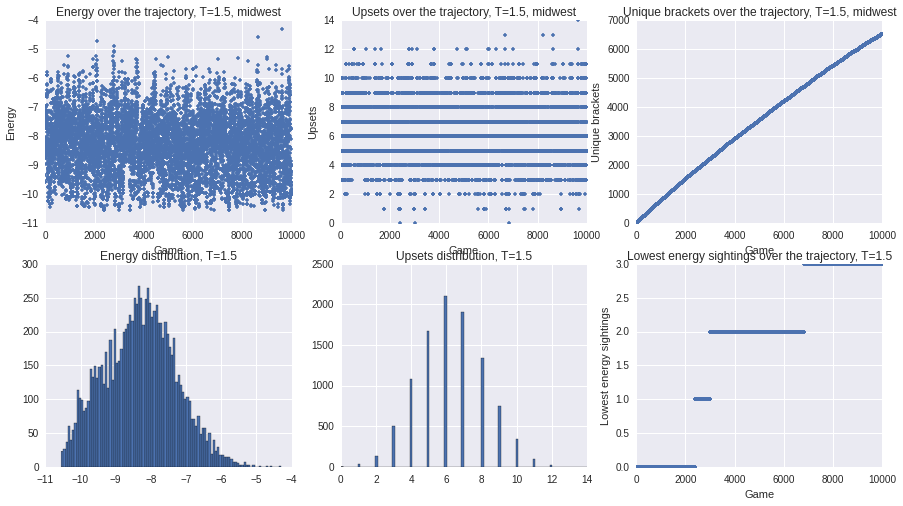

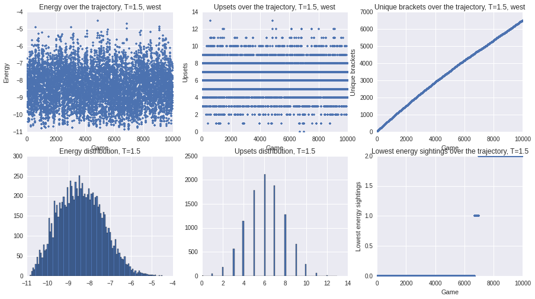

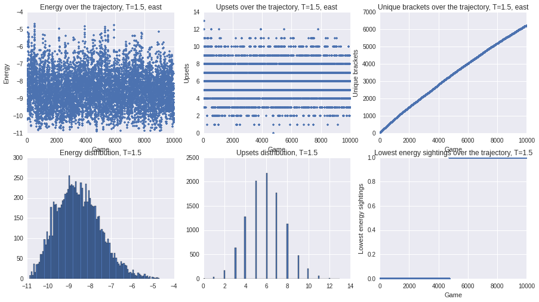

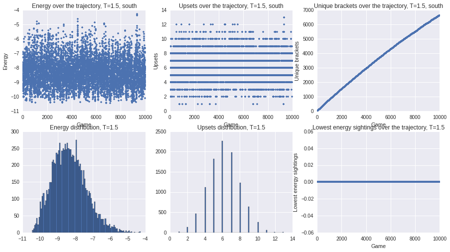

```python
# Basic visualization
for region in 'midwest west east south'.split():
    MMMC.showstats(results[region],description=region,newfig=True)
```

Here you can see the classic reason to do Monte Carlo samping in the first place: we're absolutely nowhere near fully sampling bracket space. You can tell this from each of the "Unique brackets over the trajectory" plots, none of which have leveled out.

### Nice tables

And here's our set of tabulated results. Note that things look a little funny for the Final Four: `runbracket2` runs the final four separate from the rest of the tourney. So, only four teams are allowed to have Championship and Win percentages above zero (the final four percentages are taken from the first chunk of the tourney).

```python
h = HTML(MMMC.maketable(results))
h
```

| Team | Region | Rank | 2nd Round | 3rd Round | Sweet 16 | Elite 8 | Final 4 | Championship | Win |
| --- | --- | --- | --- | --- | --- | --- | --- | --- | --- |
| Kentucky | midwest | 1 | 100.0 | 65.74 | 49.18 | 36.16 | 25.29 | 55.3 | 34.5 |
| Wisconsin | west | 1 | 100.0 | 63.38 | 44.28 | 30.04 | 19.44 | 44.7 | 24.2 |
| Virginia | east | 2 | 100.0 | 64.6 | 41.15 | 27.68 | 17.86 | 51.3 | 22.4 |
| Utah | south | 5 | 100.0 | 58.29 | 35.86 | 20.96 | 12.19 | 48.7 | 18.9 |
| Arizona | west | 2 | 100.0 | 62.35 | 42.23 | 28.64 | 18.74 | 0.0 | 0.0 |
| Villanova | east | 1 | 100.0 | 65.73 | 44.05 | 29.84 | 18.61 | 0.0 | 0.0 |
| Duke | south | 1 | 100.0 | 66.03 | 41.64 | 25.2 | 15.05 | 0.0 | 0.0 |
| Gonzaga | south | 2 | 100.0 | 61.67 | 37.12 | 23.51 | 14.22 | 0.0 | 0.0 |
| Kansas | midwest | 2 | 100.0 | 58.6 | 33.71 | 19.16 | 10.31 | 0.0 | 0.0 |
| Oklahoma | east | 3 | 100.0 | 60.74 | 34.96 | 18.34 | 10.01 | 0.0 | 0.0 |
| Northern Iowa | east | 5 | 100.0 | 65.23 | 37.58 | 19.72 | 9.97 | 0.0 | 0.0 |
| Notre Dame | midwest | 3 | 100.0 | 57.37 | 32.47 | 18.57 | 9.65 | 0.0 | 0.0 |
| Iowa St. | south | 3 | 100.0 | 57.01 | 33.22 | 17.32 | 9.07 | 0.0 | 0.0 |
| Baylor | west | 3 | 100.0 | 56.3 | 33.23 | 16.77 | 8.79 | 0.0 | 0.0 |
| North Carolina | west | 4 | 100.0 | 61.15 | 35.63 | 17.73 | 8.7 | 0.0 | 0.0 |
| SMU | south | 6 | 100.0 | 53.2 | 28.16 | 14.61 | 7.62 | 0.0 | 0.0 |
| Wichita St. | midwest | 7 | 100.0 | 51.59 | 28.31 | 15.41 | 7.54 | 0.0 | 0.0 |
| Georgetown | south | 4 | 100.0 | 60.99 | 28.74 | 15.08 | 7.37 | 0.0 | 0.0 |
| Michigan St. | east | 7 | 100.0 | 55.17 | 25.73 | 14.43 | 7.17 | 0.0 | 0.0 |
| Iowa | south | 7 | 100.0 | 51.15 | 25.99 | 13.76 | 6.63 | 0.0 | 0.0 |
| Louisville | east | 4 | 100.0 | 56.62 | 29.3 | 14.05 | 6.58 | 0.0 | 0.0 |
| West Virginia | midwest | 5 | 100.0 | 55.77 | 31.54 | 13.3 | 6.47 | 0.0 | 0.0 |
| Providence | east | 6 | 100.0 | 53.03 | 27.3 | 12.58 | 6.19 | 0.0 | 0.0 |
| Butler | midwest | 6 | 100.0 | 53.61 | 27.03 | 13.43 | 6.05 | 0.0 | 0.0 |
| Texas | midwest | 11 | 100.0 | 46.39 | 23.9 | 12.46 | 5.99 | 0.0 | 0.0 |
| Xavier | west | 6 | 100.0 | 50.71 | 25.68 | 12.46 | 5.95 | 0.0 | 0.0 |
| Ohio St. | west | 10 | 100.0 | 51.62 | 22.26 | 11.19 | 5.29 | 0.0 | 0.0 |
| Arkansas | west | 5 | 100.0 | 57.67 | 28.22 | 11.83 | 5.14 | 0.0 | 0.0 |
| Maryland | midwest | 4 | 100.0 | 55.25 | 25.84 | 11.73 | 5.14 | 0.0 | 0.0 |
| VCU | west | 7 | 100.0 | 48.38 | 21.78 | 11.24 | 5.06 | 0.0 | 0.0 |
| Oklahoma St. | west | 9 | 100.0 | 50.19 | 21.58 | 11.31 | 4.84 | 0.0 | 0.0 |
| San Diego St. | south | 8 | 100.0 | 47.92 | 23.04 | 10.71 | 4.81 | 0.0 | 0.0 |
| Oregon | west | 8 | 100.0 | 49.81 | 20.61 | 10.42 | 4.73 | 0.0 | 0.0 |
| Cincinnati | midwest | 8 | 100.0 | 49.74 | 19.41 | 9.93 | 4.72 | 0.0 | 0.0 |
| Davidson | south | 10 | 100.0 | 48.85 | 23.46 | 10.7 | 4.54 | 0.0 | 0.0 |
| LSU | east | 9 | 100.0 | 53.31 | 24.25 | 11.58 | 4.53 | 0.0 | 0.0 |
| North Carolina St. | east | 8 | 100.0 | 46.69 | 21.93 | 10.18 | 4.35 | 0.0 | 0.0 |
| Stephen F. Austin | south | 12 | 100.0 | 41.71 | 21.31 | 9.08 | 4.3 | 0.0 | 0.0 |
| UCLA | south | 11 | 100.0 | 46.8 | 21.71 | 9.51 | 4.22 | 0.0 | 0.0 |
| St. John's | south | 9 | 100.0 | 52.08 | 22.83 | 9.84 | 4.17 | 0.0 | 0.0 |
| Purdue | midwest | 9 | 100.0 | 50.26 | 19.41 | 8.86 | 3.76 | 0.0 | 0.0 |
| Buffalo | midwest | 12 | 100.0 | 44.23 | 23.13 | 8.76 | 3.55 | 0.0 | 0.0 |
| Georgia | east | 10 | 100.0 | 44.83 | 19.41 | 8.76 | 3.53 | 0.0 | 0.0 |
| Dayton | east | 11 | 100.0 | 46.97 | 22.59 | 8.55 | 3.52 | 0.0 | 0.0 |
| Mississippi | west | 11 | 100.0 | 49.29 | 21.45 | 9.01 | 3.51 | 0.0 | 0.0 |
| Indiana | midwest | 10 | 100.0 | 48.41 | 22.29 | 8.57 | 3.14 | 0.0 | 0.0 |
| Valparaiso | midwest | 13 | 100.0 | 44.75 | 19.49 | 7.86 | 3.1 | 0.0 | 0.0 |
| Georgia St. | west | 14 | 100.0 | 43.7 | 19.64 | 6.96 | 2.67 | 0.0 | 0.0 |
| Harvard | west | 13 | 100.0 | 38.85 | 18.65 | 6.98 | 2.36 | 0.0 | 0.0 |
| Wofford | west | 12 | 100.0 | 42.33 | 17.5 | 6.84 | 2.33 | 0.0 | 0.0 |
| New Mexico St. | midwest | 15 | 100.0 | 41.4 | 15.69 | 6.3 | 2.26 | 0.0 | 0.0 |
| UC Irvine | east | 13 | 100.0 | 43.38 | 19.57 | 6.64 | 2.17 | 0.0 | 0.0 |
| Northeastern | midwest | 14 | 100.0 | 42.63 | 16.6 | 6.1 | 2.17 | 0.0 | 0.0 |
| UAB | south | 14 | 100.0 | 42.99 | 16.91 | 6.09 | 2.02 | 0.0 | 0.0 |
| Wyoming | east | 12 | 100.0 | 34.77 | 13.55 | 5.06 | 1.8 | 0.0 | 0.0 |
| Albany | east | 14 | 100.0 | 39.26 | 15.15 | 4.86 | 1.59 | 0.0 | 0.0 |
| Eastern Washington | south | 13 | 100.0 | 39.01 | 14.09 | 5.06 | 1.42 | 0.0 | 0.0 |
| Coastal Carolina | west | 16 | 100.0 | 36.62 | 13.53 | 4.85 | 1.42 | 0.0 | 0.0 |
| North Dakota St. | south | 15 | 100.0 | 38.33 | 13.43 | 4.5 | 1.35 | 0.0 | 0.0 |
| Belmont | east | 15 | 100.0 | 35.4 | 13.71 | 4.8 | 1.28 | 0.0 | 0.0 |
| Texas Southern | west | 15 | 100.0 | 37.65 | 13.73 | 3.73 | 1.03 | 0.0 | 0.0 |
| Robert Morris | south | 16 | 100.0 | 33.97 | 12.49 | 4.07 | 1.02 | 0.0 | 0.0 |
| Hampton | midwest | 16 | 100.0 | 34.26 | 12.0 | 3.4 | 0.86 | 0.0 | 0.0 |
| Lafayette | east | 16 | 100.0 | 34.27 | 9.77 | 2.93 | 0.84 | 0.0 | 0.0 |

Given those concerns, let's just run `runbracket1` and look at the results

```python
results = MMMC.runbracket1(ntrials=10000,T=1.5)
```

```
Lowest energy bracket
Kentucky (1)
Hampton (16)              Ken (1)
Cincinnati (8)
Purdue (9)                Cin (8)  Ken (1)
West Virginia (5)
Buffalo (12)              Wes (5)
Maryland (4)
Valparaiso (13)           Mar (4)  Wes (5)  Ken (1)
Butler (6)
Texas (11)                Tex (11)
Notre Dame (3)
Northeastern (14)         Not (3)  Not (3)
Wichita St. (7)
Indiana (10)              Wic (7)
Kansas (2)
New Mexico St. (15)       Kan (2)  Kan (2)  Not (3)  Ken (1)
Duke (1)
Robert Morris (16)        Duk (1)
San Diego St. (8)
St. John's (9)            San (8)  Duk (1)
Utah (5)
Stephen F. Austin (12)    Uta (5)
Georgetown (4)
Eastern Washington (13)   Geo (4)  Uta (5)  Duk (1)
SMU (6)
UCLA (11)                 SMU (6)
Iowa St. (3)
UAB (14)                  Iow (3)  Iow (3)
Iowa (7)
Davidson (10)             Iow (7)
Gonzaga (2)
North Dakota St. (15)     Gon (2)  Gon (2)  Gon (2)  Gon (2)  Ken (1)
Wisconsin (1)             Wis (1)  Wis (1)  Wis (1)  Ari (2)  Ari (2)  Ken (1)
Coastal Carolina (16)
Oregon (8)                Okl (9)
Oklahoma St. (9)
Arkansas (5)              Ark (5)  Nor (4)
Wofford (12)
North Carolina (4)        Nor (4)
```

[output cut: 78 more lines]

```
North Carolina St. (8)    Nor (8)
LSU (9)
Northern Iowa (5)         Nor (5)  Nor (5)
Wyoming (12)
Louisville (4)            UC  (13)
UC Irvine (13)
Providence (6)            Pro (6)  Pro (6)  Mic (7)
Dayton (11)
Oklahoma (3)              Okl (3)
Albany (14)
Michigan St. (7)          Mic (7)  Mic (7)
Georgia (10)
Virginia (2)              Bel (15)
Belmont (15)
Total bracket energy: -38.100050778
```

```python
h = HTML(MMMC.maketable(results))
h
```

| Team | Region | Rank | 2nd Round | 3rd Round | Sweet 16 | Elite 8 | Final 4 | Championship | Win |
| --- | --- | --- | --- | --- | --- | --- | --- | --- | --- |
| Kentucky | midwest | 1 | 100.0 | 58.69 | 44.77 | 32.58 | 23.98 | 16.41 | 10.87 |
| Villanova | east | 1 | 100.0 | 65.53 | 45.71 | 32.0 | 20.87 | 13.77 | 8.67 |
| Arizona | west | 2 | 100.0 | 62.57 | 44.59 | 33.54 | 20.75 | 13.11 | 8.03 |
| Wisconsin | west | 1 | 100.0 | 67.67 | 43.02 | 27.42 | 18.12 | 11.35 | 7.15 |
| Virginia | east | 2 | 100.0 | 63.76 | 43.67 | 30.86 | 19.05 | 11.08 | 6.59 |
| Gonzaga | south | 2 | 100.0 | 57.98 | 39.95 | 25.46 | 15.02 | 9.09 | 4.78 |
| Utah | south | 5 | 100.0 | 57.92 | 34.4 | 21.04 | 13.19 | 6.8 | 3.66 |
| Duke | south | 1 | 100.0 | 60.1 | 35.45 | 18.48 | 11.41 | 6.73 | 3.49 |
| Notre Dame | midwest | 3 | 100.0 | 61.12 | 33.93 | 19.4 | 11.17 | 5.57 | 2.8 |
| Oklahoma | east | 3 | 100.0 | 62.0 | 37.74 | 17.64 | 10.01 | 5.26 | 2.64 |
| Kansas | midwest | 2 | 100.0 | 66.57 | 35.81 | 19.02 | 9.97 | 5.45 | 2.59 |
| Northern Iowa | east | 5 | 100.0 | 62.27 | 35.11 | 18.67 | 10.05 | 4.82 | 2.38 |
| Iowa St. | south | 3 | 100.0 | 60.06 | 36.95 | 20.04 | 11.12 | 5.24 | 2.36 |
| Wichita St. | midwest | 7 | 100.0 | 56.94 | 31.91 | 19.06 | 8.76 | 4.18 | 2.17 |
| North Carolina | west | 4 | 100.0 | 58.35 | 32.3 | 18.51 | 9.54 | 4.23 | 1.82 |
| SMU | south | 6 | 100.0 | 55.35 | 29.26 | 16.91 | 8.61 | 3.79 | 1.61 |
| Baylor | west | 3 | 100.0 | 56.63 | 29.51 | 11.82 | 7.12 | 3.63 | 1.56 |
| Georgetown | south | 4 | 100.0 | 56.75 | 29.58 | 15.75 | 7.23 | 3.24 | 1.42 |
| Texas | midwest | 11 | 100.0 | 58.28 | 27.89 | 14.8 | 6.87 | 3.3 | 1.39 |
| Michigan St. | east | 7 | 100.0 | 59.67 | 27.43 | 14.51 | 6.41 | 2.98 | 1.29 |
| Ohio St. | west | 10 | 100.0 | 50.4 | 23.8 | 12.61 | 6.46 | 3.19 | 1.27 |
| West Virginia | midwest | 5 | 100.0 | 58.66 | 33.41 | 13.82 | 6.62 | 2.97 | 1.17 |
| Arkansas | west | 5 | 100.0 | 57.66 | 31.16 | 12.71 | 5.34 | 2.38 | 1.16 |
| Louisville | east | 4 | 100.0 | 55.49 | 31.49 | 15.28 | 7.18 | 3.1 | 1.14 |
| Iowa | south | 7 | 100.0 | 55.68 | 25.06 | 9.92 | 5.49 | 2.67 | 1.13 |
| Butler | midwest | 6 | 100.0 | 41.72 | 24.06 | 11.13 | 6.36 | 2.77 | 1.12 |
| Xavier | west | 6 | 100.0 | 56.43 | 31.36 | 14.27 | 6.71 | 2.44 | 1.12 |
| San Diego St. | south | 8 | 100.0 | 52.15 | 29.17 | 12.83 | 6.64 | 2.88 | 1.03 |
| Cincinnati | midwest | 8 | 100.0 | 50.58 | 20.36 | 12.28 | 5.35 | 2.38 | 0.9 |
| Davidson | south | 10 | 100.0 | 44.32 | 15.66 | 6.98 | 3.12 | 1.69 | 0.73 |
| VCU | west | 7 | 100.0 | 49.6 | 19.03 | 8.63 | 4.28 | 1.81 | 0.71 |
| Maryland | midwest | 4 | 100.0 | 50.87 | 22.22 | 9.44 | 3.6 | 1.86 | 0.7 |
| Oregon | west | 8 | 100.0 | 58.41 | 24.89 | 10.74 | 4.78 | 1.74 | 0.66 |
| Stephen F. Austin | south | 12 | 100.0 | 42.08 | 23.6 | 11.54 | 4.51 | 1.72 | 0.63 |
| St. John's | south | 9 | 100.0 | 47.85 | 18.82 | 9.51 | 3.97 | 1.83 | 0.62 |
| Dayton | east | 11 | 100.0 | 48.81 | 21.64 | 8.96 | 4.31 | 1.79 | 0.58 |
| Mississippi | west | 11 | 100.0 | 43.57 | 21.86 | 8.38 | 3.0 | 1.41 | 0.55 |
| Purdue | midwest | 9 | 100.0 | 49.42 | 20.37 | 9.7 | 3.31 | 1.33 | 0.53 |
| Buffalo | midwest | 12 | 100.0 | 41.34 | 21.68 | 7.93 | 2.77 | 1.19 | 0.52 |
| Valparaiso | midwest | 13 | 100.0 | 49.13 | 22.69 | 9.34 | 4.12 | 1.49 | 0.51 |
| Providence | east | 6 | 100.0 | 51.19 | 26.68 | 11.18 | 4.28 | 1.4 | 0.48 |
| LSU | east | 9 | 100.0 | 48.81 | 15.79 | 7.11 | 2.58 | 0.92 | 0.47 |
| Georgia | east | 10 | 100.0 | 40.33 | 15.12 | 7.58 | 2.95 | 1.3 | 0.46 |
| Oklahoma St. | west | 9 | 100.0 | 41.59 | 18.78 | 9.24 | 3.35 | 1.1 | 0.45 |
| Wofford | west | 12 | 100.0 | 42.34 | 16.57 | 7.37 | 2.63 | 0.94 | 0.44 |
| Indiana | midwest | 10 | 100.0 | 43.06 | 18.98 | 8.46 | 3.72 | 1.2 | 0.43 |
| UCLA | south | 11 | 100.0 | 44.65 | 21.4 | 8.22 | 2.72 | 1.26 | 0.42 |
| North Carolina St. | east | 8 | 100.0 | 51.19 | 22.31 | 8.99 | 3.55 | 1.45 | 0.4 |
| Harvard | west | 13 | 100.0 | 41.65 | 19.97 | 8.53 | 2.49 | 0.8 | 0.35 |
| UC Irvine | east | 13 | 100.0 | 44.51 | 20.52 | 7.19 | 2.44 | 0.97 | 0.26 |
| Coastal Carolina | west | 16 | 100.0 | 32.33 | 13.31 | 5.48 | 2.24 | 0.57 | 0.24 |
| Georgia St. | west | 14 | 100.0 | 43.37 | 17.27 | 6.04 | 1.92 | 0.47 | 0.21 |
| UAB | south | 14 | 100.0 | 39.94 | 12.39 | 4.94 | 1.57 | 0.73 | 0.17 |
| Eastern Washington | south | 13 | 100.0 | 43.25 | 12.42 | 3.88 | 1.27 | 0.55 | 0.17 |
| Lafayette | east | 16 | 100.0 | 34.47 | 16.19 | 7.11 | 2.28 | 0.5 | 0.15 |
| Wyoming | east | 12 | 100.0 | 37.73 | 12.88 | 3.65 | 1.12 | 0.4 | 0.15 |
| Albany | east | 14 | 100.0 | 38.0 | 13.94 | 4.57 | 1.84 | 0.53 | 0.11 |
| Robert Morris | south | 16 | 100.0 | 39.9 | 16.56 | 6.97 | 2.39 | 0.5 | 0.11 |
| Belmont | east | 15 | 100.0 | 36.24 | 13.78 | 4.7 | 1.08 | 0.31 | 0.11 |
| Texas Southern | west | 15 | 100.0 | 37.43 | 12.58 | 4.71 | 1.27 | 0.25 | 0.11 |
| Northeastern | midwest | 14 | 100.0 | 38.88 | 14.12 | 4.28 | 0.99 | 0.29 | 0.09 |
| Hampton | midwest | 16 | 100.0 | 41.31 | 14.5 | 4.91 | 1.25 | 0.25 | 0.07 |
| North Dakota St. | south | 15 | 100.0 | 42.02 | 19.33 | 7.53 | 1.74 | 0.33 | 0.05 |
| New Mexico St. | midwest | 15 | 100.0 | 33.43 | 13.3 | 3.85 | 1.16 | 0.31 | 0.05 |

That is, indeed, high temperature! Let's try it with a bunch more runs

```python
results = MMMC.runbracket1(ntrials=100000,T=1.5)
```

```
Lowest energy bracket
Kentucky (1)
Hampton (16)              Ken (1)
Cincinnati (8)
Purdue (9)                Cin (8)  Ken (1)
West Virginia (5)
Buffalo (12)              Wes (5)
Maryland (4)
Valparaiso (13)           Mar (4)  Wes (5)  Ken (1)
Butler (6)
Texas (11)                Tex (11)
Notre Dame (3)
Northeastern (14)         Not (3)  Not (3)
Wichita St. (7)
Indiana (10)              Wic (7)
Kansas (2)
New Mexico St. (15)       Kan (2)  Kan (2)  Not (3)  Ken (1)
Duke (1)
Robert Morris (16)        Duk (1)
San Diego St. (8)
St. John's (9)            San (8)  Duk (1)
Utah (5)
Stephen F. Austin (12)    Uta (5)
Georgetown (4)
Eastern Washington (13)   Geo (4)  Uta (5)  Duk (1)
SMU (6)
UCLA (11)                 SMU (6)
Iowa St. (3)
UAB (14)                  Iow (3)  Iow (3)
Iowa (7)
Davidson (10)             Iow (7)
Gonzaga (2)
North Dakota St. (15)     Gon (2)  Gon (2)  Gon (2)  Gon (2)  Ken (1)
Wisconsin (1)             Wis (1)  Wis (1)  Wis (1)  Ari (2)  Ari (2)  Ken (1)
Coastal Carolina (16)
Oregon (8)                Okl (9)
Oklahoma St. (9)
Arkansas (5)              Ark (5)  Nor (4)
Wofford (12)
North Carolina (4)        Nor (4)
```

[output cut: 78 more lines]

```
North Carolina St. (8)    LSU (9)
LSU (9)
Northern Iowa (5)         Nor (5)  Lou (4)
Wyoming (12)
Louisville (4)            Lou (4)
UC Irvine (13)
Providence (6)            Day (11) Alb (14) Vir (2)
Dayton (11)
Oklahoma (3)              Alb (14)
Albany (14)
Michigan St. (7)          Mic (7)  Vir (2)
Georgia (10)
Virginia (2)              Vir (2)
Belmont (15)
Total bracket energy: -37.1483683417
```

```python
h = HTML(MMMC.maketable(results))
h
```

| Team | Region | Rank | 2nd Round | 3rd Round | Sweet 16 | Elite 8 | Final 4 | Championship | Win |
| --- | --- | --- | --- | --- | --- | --- | --- | --- | --- |
| Kentucky | midwest | 1 | 100.0 | 67.848 | 49.189 | 36.444 | 26.79 | 18.949 | 12.828 |
| Arizona | west | 2 | 100.0 | 64.114 | 42.628 | 29.248 | 18.838 | 12.256 | 7.805 |
| Wisconsin | west | 1 | 100.0 | 63.368 | 42.146 | 28.131 | 17.705 | 11.083 | 6.862 |
| Villanova | east | 1 | 100.0 | 64.314 | 43.814 | 28.618 | 17.425 | 10.64 | 6.365 |
| Virginia | east | 2 | 100.0 | 62.189 | 39.522 | 26.285 | 17.038 | 10.321 | 6.183 |
| Gonzaga | south | 2 | 100.0 | 61.672 | 38.305 | 24.17 | 14.417 | 8.149 | 4.538 |
| Duke | south | 1 | 100.0 | 64.407 | 40.263 | 24.75 | 14.927 | 8.061 | 4.37 |
| Oklahoma | east | 3 | 100.0 | 62.257 | 38.005 | 20.227 | 11.564 | 5.906 | 3.04 |
| Utah | south | 5 | 100.0 | 56.188 | 34.295 | 19.469 | 10.846 | 5.576 | 2.832 |
| Notre Dame | midwest | 3 | 100.0 | 60.692 | 33.504 | 18.74 | 9.665 | 5.061 | 2.473 |
| Kansas | midwest | 2 | 100.0 | 59.732 | 33.553 | 18.682 | 9.098 | 4.834 | 2.329 |
| Northern Iowa | east | 5 | 100.0 | 58.928 | 34.06 | 17.509 | 9.302 | 4.604 | 2.239 |
| North Carolina | west | 4 | 100.0 | 61.148 | 36.852 | 19.086 | 9.535 | 4.682 | 2.223 |
| Iowa St. | south | 3 | 100.0 | 59.581 | 33.405 | 18.131 | 9.562 | 4.647 | 2.206 |
| Baylor | west | 3 | 100.0 | 58.599 | 34.549 | 16.969 | 9.177 | 4.63 | 2.202 |
| Wichita St. | midwest | 7 | 100.0 | 56.45 | 31.005 | 17.065 | 8.454 | 4.378 | 2.104 |
| Louisville | east | 4 | 100.0 | 56.525 | 30.188 | 15.331 | 6.889 | 3.158 | 1.413 |
| Texas | midwest | 11 | 100.0 | 52.783 | 28.184 | 14.644 | 6.604 | 3.115 | 1.372 |
| SMU | south | 6 | 100.0 | 54.37 | 29.068 | 14.489 | 6.789 | 3.097 | 1.361 |
| Georgetown | south | 4 | 100.0 | 58.912 | 28.238 | 14.08 | 6.915 | 3.015 | 1.311 |
| Michigan St. | east | 7 | 100.0 | 55.477 | 25.467 | 12.998 | 6.372 | 2.951 | 1.292 |
| Ohio St. | west | 10 | 100.0 | 50.1 | 23.617 | 12.158 | 5.813 | 2.825 | 1.18 |
| West Virginia | midwest | 5 | 100.0 | 52.507 | 28.241 | 12.365 | 5.829 | 2.809 | 1.09 |
| Butler | midwest | 6 | 100.0 | 47.217 | 24.427 | 12.449 | 5.551 | 2.47 | 1.088 |
| Iowa | south | 7 | 100.0 | 51.023 | 24.916 | 12.842 | 6.02 | 2.641 | 1.084 |
| Arkansas | west | 5 | 100.0 | 58.71 | 28.683 | 13.046 | 5.712 | 2.619 | 1.074 |
| San Diego St. | south | 8 | 100.0 | 52.821 | 25.262 | 12.281 | 5.721 | 2.585 | 1.026 |
| Xavier | west | 6 | 100.0 | 52.833 | 26.252 | 11.254 | 5.424 | 2.318 | 0.966 |
| VCU | west | 7 | 100.0 | 49.9 | 22.655 | 11.034 | 5.322 | 2.272 | 0.915 |
| Davidson | south | 10 | 100.0 | 48.977 | 23.746 | 11.654 | 5.393 | 2.259 | 0.887 |
| Maryland | midwest | 4 | 100.0 | 54.293 | 27.841 | 10.992 | 4.69 | 2.124 | 0.852 |
| Cincinnati | midwest | 8 | 100.0 | 49.481 | 21.064 | 10.878 | 4.977 | 2.137 | 0.809 |
| Providence | east | 6 | 100.0 | 50.52 | 23.839 | 10.379 | 4.86 | 1.981 | 0.778 |
| North Carolina St. | east | 8 | 100.0 | 52.32 | 22.887 | 11.35 | 4.862 | 1.818 | 0.717 |
| Oregon | west | 8 | 100.0 | 50.892 | 22.58 | 10.956 | 4.322 | 1.844 | 0.7 |
| St. John's | south | 9 | 100.0 | 47.179 | 22.962 | 10.652 | 4.691 | 1.904 | 0.687 |
| Stephen F. Austin | south | 12 | 100.0 | 43.812 | 22.666 | 9.837 | 4.551 | 1.859 | 0.674 |
| Oklahoma St. | west | 9 | 100.0 | 49.108 | 21.697 | 10.965 | 4.484 | 1.736 | 0.666 |
| Georgia | east | 10 | 100.0 | 44.523 | 21.647 | 10.237 | 4.523 | 1.723 | 0.65 |
| Dayton | east | 11 | 100.0 | 49.48 | 22.922 | 9.937 | 4.078 | 1.609 | 0.594 |
| LSU | east | 9 | 100.0 | 47.68 | 20.72 | 9.64 | 3.961 | 1.595 | 0.584 |
| UCLA | south | 11 | 100.0 | 45.63 | 22.264 | 9.285 | 3.921 | 1.548 | 0.559 |
| Mississippi | west | 11 | 100.0 | 47.167 | 20.522 | 8.975 | 3.684 | 1.45 | 0.53 |
| Buffalo | midwest | 12 | 100.0 | 47.493 | 23.217 | 8.816 | 3.647 | 1.519 | 0.525 |
| Purdue | midwest | 9 | 100.0 | 50.519 | 19.548 | 9.389 | 3.926 | 1.513 | 0.503 |
| Indiana | midwest | 10 | 100.0 | 43.55 | 19.487 | 8.32 | 3.427 | 1.3 | 0.446 |
| Valparaiso | midwest | 13 | 100.0 | 45.707 | 20.701 | 8.106 | 3.225 | 1.236 | 0.43 |
| Georgia St. | west | 14 | 100.0 | 41.401 | 18.677 | 6.87 | 2.788 | 0.94 | 0.321 |
| Harvard | west | 13 | 100.0 | 38.852 | 17.912 | 7.032 | 2.36 | 0.872 | 0.269 |
| UC Irvine | east | 13 | 100.0 | 43.475 | 18.635 | 7.212 | 2.373 | 0.699 | 0.232 |
| Wofford | west | 12 | 100.0 | 41.29 | 16.553 | 5.962 | 2.169 | 0.686 | 0.214 |
| Wyoming | east | 12 | 100.0 | 41.072 | 17.117 | 6.21 | 2.154 | 0.697 | 0.194 |
| New Mexico St. | midwest | 15 | 100.0 | 40.268 | 15.955 | 5.428 | 1.908 | 0.604 | 0.167 |
| UAB | south | 14 | 100.0 | 40.419 | 15.263 | 4.757 | 1.649 | 0.545 | 0.153 |
| Northeastern | midwest | 14 | 100.0 | 39.308 | 13.885 | 4.672 | 1.41 | 0.479 | 0.145 |
| Belmont | east | 15 | 100.0 | 37.811 | 13.364 | 4.884 | 1.732 | 0.534 | 0.144 |
| Albany | east | 14 | 100.0 | 37.743 | 15.234 | 5.053 | 1.602 | 0.465 | 0.14 |
| Eastern Washington | south | 13 | 100.0 | 41.088 | 14.801 | 5.269 | 1.861 | 0.544 | 0.139 |
| Coastal Carolina | west | 16 | 100.0 | 36.632 | 13.577 | 4.822 | 1.707 | 0.492 | 0.126 |
| North Dakota St. | south | 15 | 100.0 | 38.328 | 13.033 | 4.672 | 1.602 | 0.478 | 0.121 |
| Lafayette | east | 16 | 100.0 | 35.686 | 12.579 | 4.13 | 1.265 | 0.31 | 0.078 |
| Robert Morris | south | 16 | 100.0 | 35.593 | 11.513 | 3.662 | 1.135 | 0.33 | 0.073 |
| Texas Southern | west | 15 | 100.0 | 35.886 | 11.1 | 3.492 | 0.96 | 0.284 | 0.066 |
| Hampton | midwest | 16 | 100.0 | 32.152 | 10.199 | 3.01 | 0.799 | 0.234 | 0.056 |

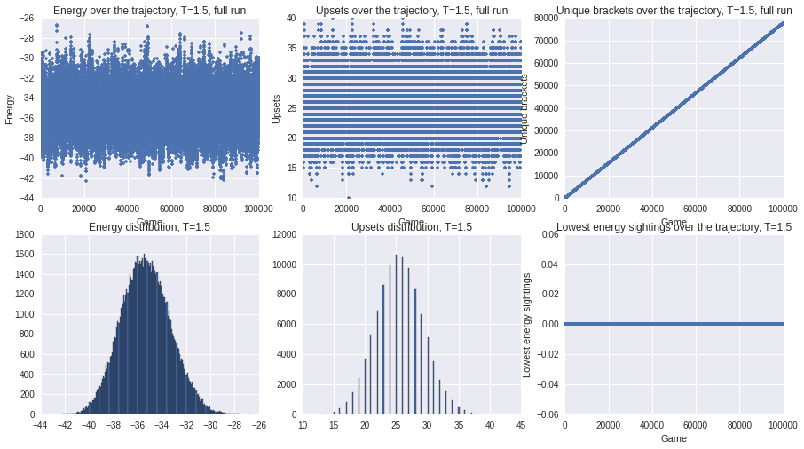

```python
MMMC.showstats(results['all'],description='full run',newfig=True)
```

Not bad! (Also, note the shape of the energy distribution, and the fact taht the "Unique brackets" group is still basically linear!)

## Who wins?

But let's be honest for a minute. We all know Kansas is going to win. What do the brackets where that happened look like?

```python
goodbrackets = [i for i in results['all'].brackets if i.bracket[-1][0] == 'Kansas']
```

```python
from MarchMadnessMonteCarlo.Brackets import Stats
lb, mcb, mcb_count, unique_brackets, lowest_sightings = Stats.gather_uniquestats(goodbrackets)
sr = MMMC.SimulationResults(goodbrackets,unique_brackets,lb,lowest_sightings,mcb,mcb_count)
trueresults = {'all':sr}
```

```python
h = HTML(MMMC.maketable(trueresults))
h
```

| Team | Region | Rank | 2nd Round | 3rd Round | Sweet 16 | Elite 8 | Final 4 | Championship | Win |
| --- | --- | --- | --- | --- | --- | --- | --- | --- | --- |
| Kansas | midwest | 2 | 100.0 | 100.0 | 100.0 | 100.0 | 100.0 | 100.0 | 100.0 |
| Virginia | east | 2 | 100.0 | 61.743237441 | 39.7595534564 | 25.7621296694 | 17.1318162301 | 9.01674538429 | 0.0 |
| Villanova | east | 1 | 100.0 | 68.05495921 | 47.8316874195 | 30.8286818377 | 17.3894375268 | 8.71618720481 | 0.0 |
| Wisconsin | west | 1 | 100.0 | 62.0008587377 | 39.5019321597 | 24.9033920137 | 14.2121082009 | 8.2438814942 | 0.0 |
| Oklahoma | east | 3 | 100.0 | 63.8042078145 | 42.7221983684 | 22.4130528124 | 13.0957492486 | 7.7715757836 | 0.0 |
| Arizona | west | 2 | 100.0 | 62.9025332761 | 37.5697724345 | 24.4310863031 | 14.6414770288 | 7.72863890082 | 0.0 |
| Northern Iowa | east | 5 | 100.0 | 59.5534564191 | 37.1404036067 | 18.3769858308 | 10.5195362817 | 5.45298411335 | 0.0 |
| Baylor | west | 3 | 100.0 | 55.3456419064 | 30.9145556033 | 15.5431515672 | 9.05968226707 | 4.89480463718 | 0.0 |
| North Carolina | west | 4 | 100.0 | 58.8664662945 | 35.4229282954 | 19.321597252 | 9.61786174324 | 4.8518677544 | 0.0 |
| Michigan St. | east | 7 | 100.0 | 57.4924860455 | 26.4920566767 | 12.7951910691 | 6.26878488622 | 3.47788750537 | 0.0 |
| Louisville | east | 4 | 100.0 | 58.3082868184 | 29.2400171748 | 14.1262344354 | 6.82696436239 | 3.30613997424 | 0.0 |
| Xavier | west | 6 | 100.0 | 50.1502790897 | 25.1610133104 | 11.9793902963 | 7.29927007299 | 3.17732932589 | 0.0 |
| Oregon | west | 8 | 100.0 | 52.2112494633 | 22.4559896951 | 12.2799484757 | 5.28123658222 | 2.9197080292 | 0.0 |
| Ohio St. | west | 10 | 100.0 | 50.493774152 | 26.8355517389 | 13.6539287248 | 5.53885787892 | 2.79089738085 | 0.0 |
| Arkansas | west | 5 | 100.0 | 60.3263203091 | 28.9823958781 | 11.8935165307 | 5.88235294118 | 2.70502361529 | 0.0 |
| VCU | west | 7 | 100.0 | 49.506225848 | 23.5723486475 | 12.1082009446 | 5.83941605839 | 2.53327608416 | 0.0 |
| Providence | east | 6 | 100.0 | 51.1807642765 | 21.4255045084 | 9.44611421211 | 4.46543580936 | 2.44740231859 | 0.0 |
| North Carolina St. | east | 8 | 100.0 | 55.3885787892 | 24.6887075998 | 13.009875483 | 4.8518677544 | 2.14684413912 | 0.0 |
| Mississippi | west | 11 | 100.0 | 49.8497209103 | 24.6887075998 | 10.9489051095 | 4.76599398884 | 1.9321597252 | 0.0 |
| Dayton | east | 11 | 100.0 | 48.8192357235 | 20.0085873766 | 9.14555603263 | 4.03606698154 | 1.9321597252 | 0.0 |
| Oklahoma St. | west | 9 | 100.0 | 47.7887505367 | 22.0695577501 | 11.5500214684 | 4.20781451267 | 1.71747531129 | 0.0 |
| Georgia St. | west | 14 | 100.0 | 44.6543580936 | 19.2357234865 | 7.64276513525 | 3.82138256763 | 1.71747531129 | 0.0 |
| Georgia | east | 10 | 100.0 | 42.5075139545 | 20.6097037355 | 9.40317732933 | 3.60669815371 | 1.63160154573 | 0.0 |
| Harvard | west | 13 | 100.0 | 41.1335337055 | 20.0515242593 | 8.41562902533 | 3.34907685702 | 1.58866466295 | 0.0 |
| Wofford | west | 12 | 100.0 | 39.6736796909 | 15.5431515672 | 5.88235294118 | 2.9197080292 | 1.37398024903 | 0.0 |
| LSU | east | 9 | 100.0 | 44.6114212108 | 18.3769858308 | 8.75912408759 | 3.69257191928 | 1.33104336625 | 0.0 |
| Belmont | east | 15 | 100.0 | 38.256762559 | 13.1386861314 | 6.65521683126 | 2.10390725633 | 1.07342206956 | 0.0 |
| Coastal Carolina | west | 16 | 100.0 | 37.9991412623 | 15.972520395 | 5.75354229283 | 2.36152855303 | 0.901674538429 | 0.0 |
| Wyoming | east | 12 | 100.0 | 40.4465435809 | 17.1747531129 | 5.5817947617 | 1.71747531129 | 0.686990124517 | 0.0 |
| UC Irvine | east | 13 | 100.0 | 41.6917131816 | 16.4448261056 | 5.66766852726 | 1.63160154573 | 0.515242593388 | 0.0 |
| Texas Southern | west | 15 | 100.0 | 37.0974667239 | 12.022327179 | 3.69257191928 | 1.2022327179 | 0.515242593388 | 0.0 |
| Lafayette | east | 16 | 100.0 | 31.94504079 | 9.10261914985 | 3.6496350365 | 1.15929583512 | 0.472305710605 | 0.0 |
| Albany | east | 14 | 100.0 | 36.1957921855 | 15.8437097467 | 4.3795620438 | 1.50279089738 | 0.429368827823 | 0.0 |
| Duke | south | 1 | 100.0 | 61.8291112065 | 40.1459854015 | 22.1124946329 | 13.5680549592 | 0.0 | 0.0 |
| Gonzaga | south | 2 | 100.0 | 55.5173894375 | 35.0364963504 | 21.4684413912 | 10.0472305711 | 0.0 | 0.0 |
| Utah | south | 5 | 100.0 | 54.8733361958 | 30.184628596 | 15.8866466295 | 9.7037355088 | 0.0 | 0.0 |
| Iowa St. | south | 3 | 100.0 | 59.167024474 | 32.546157149 | 17.9905538858 | 9.36024044654 | 0.0 | 0.0 |
| Georgetown | south | 4 | 100.0 | 58.780592529 | 30.184628596 | 16.1013310434 | 8.54443967368 | 0.0 | 0.0 |
| St. John's | south | 9 | 100.0 | 49.0339201374 | 23.7011592958 | 13.7827393731 | 6.86990124517 | 0.0 | 0.0 |
| Stephen F. Austin | south | 12 | 100.0 | 45.1266638042 | 24.9033920137 | 10.261914985 | 6.39759553456 | 0.0 | 0.0 |
| SMU | south | 6 | 100.0 | 54.6157148991 | 27.6513525118 | 13.8686131387 | 6.35465865178 | 0.0 | 0.0 |
| Davidson | south | 10 | 100.0 | 48.6045513096 | 24.3022756548 | 12.022327179 | 5.5817947617 | 0.0 | 0.0 |
| San Diego St. | south | 8 | 100.0 | 50.9660798626 | 22.6706741091 | 12.2799484757 | 5.49592099614 | 0.0 | 0.0 |
| Iowa | south | 7 | 100.0 | 51.3954486904 | 24.4740231859 | 12.5375697724 | 5.45298411335 | 0.0 | 0.0 |
| UCLA | south | 11 | 100.0 | 45.3842851009 | 23.1000429369 | 11.1635895234 | 5.06655216831 | 0.0 | 0.0 |
| Eastern Washington | south | 13 | 100.0 | 41.219407471 | 14.7273507943 | 5.88235294118 | 2.49033920137 | 0.0 | 0.0 |
| North Dakota St. | south | 15 | 100.0 | 44.4826105625 | 16.1872048089 | 6.18291112065 | 2.06097037355 | 0.0 | 0.0 |
| UAB | south | 14 | 100.0 | 40.832975526 | 16.7024474023 | 4.76599398884 | 1.84628595964 | 0.0 | 0.0 |
| Robert Morris | south | 16 | 100.0 | 38.1708887935 | 13.4821811936 | 3.69257191928 | 1.15929583512 | 0.0 | 0.0 |
| Kentucky | midwest | 1 | 100.0 | 61.743237441 | 39.6307428081 | 21.8119364534 | 0.0 | 0.0 | 0.0 |
| Maryland | midwest | 4 | 100.0 | 59.4246457707 | 31.2151137827 | 16.3160154573 | 0.0 | 0.0 | 0.0 |
| Purdue | midwest | 9 | 100.0 | 55.7320738514 | 27.4796049807 | 13.3963074281 | 0.0 | 0.0 | 0.0 |
| Buffalo | midwest | 12 | 100.0 | 47.7458136539 | 24.4310863031 | 12.2799484757 | 0.0 | 0.0 | 0.0 |
| West Virginia | midwest | 5 | 100.0 | 52.2541863461 | 23.7440961786 | 11.8076427651 | 0.0 | 0.0 | 0.0 |
| Valparaiso | midwest | 13 | 100.0 | 40.5753542293 | 20.6097037355 | 9.9613568055 | 0.0 | 0.0 | 0.0 |
| Cincinnati | midwest | 8 | 100.0 | 44.2679261486 | 20.5238299699 | 9.9613568055 | 0.0 | 0.0 | 0.0 |
| Hampton | midwest | 16 | 100.0 | 38.256762559 | 12.3658222413 | 4.46543580936 | 0.0 | 0.0 | 0.0 |
| Texas | midwest | 11 | 100.0 | 51.5671962216 | 30.9145556033 | 0.0 | 0.0 | 0.0 | 0.0 |
| Notre Dame | midwest | 3 | 100.0 | 58.4800343495 | 30.2275654787 | 0.0 | 0.0 | 0.0 | 0.0 |
| Butler | midwest | 6 | 100.0 | 48.4328037784 | 23.0141691713 | 0.0 | 0.0 | 0.0 | 0.0 |
| Northeastern | midwest | 14 | 100.0 | 41.5199656505 | 15.8437097467 | 0.0 | 0.0 | 0.0 | 0.0 |
| Wichita St. | midwest | 7 | 100.0 | 55.2168312581 | 0.0 | 0.0 | 0.0 | 0.0 | 0.0 |
| Indiana | midwest | 10 | 100.0 | 44.7831687419 | 0.0 | 0.0 | 0.0 | 0.0 | 0.0 |
| New Mexico St. | midwest | 15 | 100.0 | 0.0 | 0.0 | 0.0 | 0.0 | 0.0 | 0.0 |

```python
sr.most_common_bracket
```

```
Kentucky (1)
Hampton (16)              Ham (16)
Cincinnati (8)
Purdue (9)                Pur (9)  Pur (9)
West Virginia (5)
Buffalo (12)              Buf (12)
Maryland (4)
Valparaiso (13)           Val (13) Buf (12) Pur (9)
Butler (6)
Texas (11)                Tex (11)
Notre Dame (3)
Northeastern (14)         Not (3)  Not (3)
Wichita St. (7)
Indiana (10)              Ind (10)
Kansas (2)
New Mexico St. (15)       Kan (2)  Kan (2)  Kan (2)  Kan (2)
Duke (1)
Robert Morris (16)        Duk (1)
San Diego St. (8)
St. John's (9)            St. (9)  Duk (1)
Utah (5)
Stephen F. Austin (12)    Ste (12)
Georgetown (4)
Eastern Washington (13)   Geo (4)  Ste (12) Ste (12)
SMU (6)
UCLA (11)                 SMU (6)
Iowa St. (3)
UAB (14)                  Iow (3)  SMU (6)
Iowa (7)
Davidson (10)             Iow (7)
Gonzaga (2)
North Dakota St. (15)     Gon (2)  Gon (2)  Gon (2)  Ste (12) Kan (2)
Wisconsin (1)             Wis (1)  Okl (9)  Wof (12) Wof (12) Okl (3)  Kan (2)
Coastal Carolina (16)
Oregon (8)                Okl (9)
Oklahoma St. (9)
Arkansas (5)              Wof (12) Wof (12)
Wofford (12)
North Carolina (4)        Har (13)
Harvard (13)
```

[output cut: 10 more lines]

```
North Carolina St. (8)    Nor (8)
LSU (9)
Northern Iowa (5)         Wyo (12) Lou (4)
Wyoming (12)
Louisville (4)            Lou (4)
UC Irvine (13)
Providence (6)            Pro (6)  Okl (3)  Okl (3)
Dayton (11)
Oklahoma (3)              Okl (3)
Albany (14)
Michigan St. (7)          Mic (7)  Mic (7)
Georgia (10)
Virginia (2)              Vir (2)
Belmont (15)
Total bracket energy: -35.9796902956
```

```python
sr.most_common_bracket_count
```

```
4
```

Huh. Well, that's not exactly my pick for best bracket, but there you have it.

Excersizes for the reader:

- make a better energy function, using maybe a weighted average of different rankings. I slurped in KenPom and Jeff Sagarin, but you could add your own.
- come up with a better "hometown wins" version. E.g. explicitly check for KU, and tweak the rankings.

```python
from MarchMadnessMonteCarlo import RankingsAndStrength as RAS
strength = RAS.kenpom['Pyth']
jsstrength = RAS.sagarin['Rating']

def weighted_KU_energy_game(winner, loser):
    if winner == 'Kansas':
        win_pct = 0.99
    elif loser == 'Kansas':
        win_pct = 0.01
    else:
        A,B = strength[winner],strength[loser]
        # see http://207.56.97.150/articles/playoff2002.htm
        kenpom = (A-A*B)/(A+B-2*A*B)
        A,B = jsstrength[winner]/100, jsstrength[loser]/100
        A,B = min(A,0.9999),min(B,0.9999)
        sagarin = (A-A*B)/(A+B-2*A*B)
        win_pct = 0.70*kenpom + 0.30*sagarin
    return -win_pct
```

```python
MMMC.set_energy_function(weighted_KU_energy_game)
```

```python
results = MMMC.runbracket1(ntrials=100000,T=1.5)
```

```
Lowest energy bracket
Kentucky (1)
Hampton (16)              Ken (1)
Cincinnati (8)
Purdue (9)                Cin (8)  Ken (1)
West Virginia (5)
Buffalo (12)              Wes (5)
Maryland (4)
Valparaiso (13)           Mar (4)  Wes (5)  Ken (1)
Butler (6)
Texas (11)                Tex (11)
Notre Dame (3)
Northeastern (14)         Not (3)  Not (3)
Wichita St. (7)
Indiana (10)              Wic (7)
Kansas (2)
New Mexico St. (15)       Kan (2)  Kan (2)  Kan (2)  Kan (2)
Duke (1)
Robert Morris (16)        Duk (1)
San Diego St. (8)
St. John's (9)            San (8)  Duk (1)
Utah (5)
Stephen F. Austin (12)    Uta (5)
Georgetown (4)
Eastern Washington (13)   Geo (4)  Uta (5)  Duk (1)
SMU (6)
UCLA (11)                 SMU (6)
Iowa St. (3)
UAB (14)                  Iow (3)  Iow (3)
Iowa (7)
Davidson (10)             Iow (7)
Gonzaga (2)
North Dakota St. (15)     Gon (2)  Gon (2)  Gon (2)  Duk (1)  Kan (2)
Wisconsin (1)             Wis (1)  Wis (1)  Wis (1)  Ari (2)  Ari (2)  Kan (2)
Coastal Carolina (16)
Oregon (8)                Okl (9)
Oklahoma St. (9)
Arkansas (5)              Ark (5)  Nor (4)
Wofford (12)
North Carolina (4)        Nor (4)
```

[output cut: 78 more lines]

```
North Carolina St. (8)    Nor (8)
LSU (9)
Northern Iowa (5)         Nor (5)  Lou (4)
Wyoming (12)
Louisville (4)            Lou (4)
UC Irvine (13)
Providence (6)            Pro (6)  Okl (3)  Mic (7)
Dayton (11)
Oklahoma (3)              Okl (3)
Albany (14)
Michigan St. (7)          Mic (7)  Mic (7)
Georgia (10)
Virginia (2)              Bel (15)
Belmont (15)
Total bracket energy: -38.9077921757
```

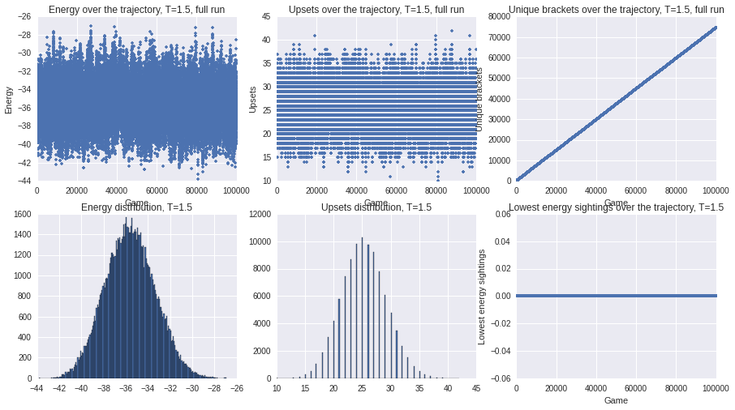

```python
MMMC.showstats(results['all'],description='full run',newfig=True)
```

```python
h = HTML(MMMC.maketable(results))
h
```

| Team | Region | Rank | 2nd Round | 3rd Round | Sweet 16 | Elite 8 | Final 4 | Championship | Win |
| --- | --- | --- | --- | --- | --- | --- | --- | --- | --- |
| Kansas | midwest | 2 | 100.0 | 71.415 | 55.343 | 44.429 | 35.557 | 28.44 | 22.414 |
| Kentucky | midwest | 1 | 100.0 | 69.107 | 50.644 | 37.446 | 18.891 | 13.788 | 9.643 |
| Arizona | west | 2 | 100.0 | 65.022 | 43.251 | 29.626 | 19.515 | 12.801 | 6.535 |
| Wisconsin | west | 1 | 100.0 | 64.476 | 43.066 | 29.09 | 17.775 | 11.201 | 5.467 |
| Virginia | east | 2 | 100.0 | 65.076 | 42.901 | 28.131 | 17.706 | 10.58 | 5.127 |
| Villanova | east | 1 | 100.0 | 63.795 | 42.213 | 27.546 | 17.299 | 10.203 | 4.848 |
| Duke | south | 1 | 100.0 | 63.066 | 40.645 | 25.96 | 15.924 | 6.731 | 3.64 |
| Gonzaga | south | 2 | 100.0 | 62.557 | 37.869 | 24.019 | 14.332 | 6.157 | 3.354 |
| Utah | south | 5 | 100.0 | 54.831 | 33.958 | 18.603 | 10.684 | 4.171 | 2.105 |
| North Carolina | west | 4 | 100.0 | 55.798 | 35.168 | 18.059 | 9.103 | 4.648 | 1.857 |
| Oklahoma | east | 3 | 100.0 | 57.558 | 32.89 | 16.602 | 8.699 | 4.476 | 1.856 |
| Iowa St. | south | 3 | 100.0 | 58.435 | 32.387 | 17.002 | 9.079 | 3.519 | 1.74 |
| Baylor | west | 3 | 100.0 | 57.425 | 33.143 | 16.356 | 8.703 | 4.328 | 1.714 |
| Northern Iowa | east | 5 | 100.0 | 58.362 | 33.246 | 16.966 | 8.687 | 4.148 | 1.653 |
| Notre Dame | midwest | 3 | 100.0 | 58.973 | 33.146 | 12.23 | 5.888 | 3.064 | 1.459 |
| Louisville | east | 4 | 100.0 | 56.572 | 30.948 | 15.201 | 7.349 | 3.329 | 1.289 |
| Wichita St. | midwest | 7 | 100.0 | 55.022 | 19.553 | 10.731 | 5.057 | 2.614 | 1.235 |
| Michigan St. | east | 7 | 100.0 | 53.365 | 25.012 | 13.642 | 6.637 | 3.041 | 1.157 |
| Ohio St. | west | 10 | 100.0 | 50.97 | 23.373 | 12.8 | 6.241 | 2.876 | 1.053 |
| Georgetown | south | 4 | 100.0 | 56.351 | 27.242 | 13.727 | 6.735 | 2.386 | 1.046 |
| SMU | south | 6 | 100.0 | 50.545 | 26.664 | 12.96 | 6.318 | 2.197 | 0.98 |
| Iowa | south | 7 | 100.0 | 53.959 | 26.803 | 13.763 | 6.446 | 2.273 | 0.979 |
| Xavier | west | 6 | 100.0 | 54.002 | 25.958 | 11.422 | 5.532 | 2.541 | 0.936 |
| West Virginia | midwest | 5 | 100.0 | 55.439 | 30.487 | 13.026 | 4.733 | 2.187 | 0.896 |
| Providence | east | 6 | 100.0 | 54.017 | 27.975 | 12.282 | 5.736 | 2.417 | 0.88 |
| Arkansas | west | 5 | 100.0 | 55.043 | 25.753 | 11.997 | 5.229 | 2.275 | 0.845 |
| Texas | midwest | 11 | 100.0 | 51.713 | 25.828 | 9.107 | 4.172 | 1.938 | 0.84 |
| San Diego St. | south | 8 | 100.0 | 49.116 | 22.93 | 11.033 | 5.181 | 1.853 | 0.755 |
| VCU | west | 7 | 100.0 | 49.03 | 21.187 | 9.927 | 4.523 | 1.995 | 0.744 |
| Maryland | midwest | 4 | 100.0 | 53.53 | 26.132 | 10.837 | 4.056 | 1.82 | 0.735 |
| Butler | midwest | 6 | 100.0 | 48.287 | 23.838 | 8.227 | 3.593 | 1.688 | 0.694 |
| Davidson | south | 10 | 100.0 | 46.041 | 21.646 | 10.642 | 4.871 | 1.683 | 0.678 |
| Oklahoma St. | west | 9 | 100.0 | 50.857 | 22.453 | 11.343 | 4.682 | 1.87 | 0.671 |
| North Carolina St. | east | 8 | 100.0 | 51.914 | 22.439 | 11.07 | 4.813 | 1.896 | 0.611 |
| St. John's | south | 9 | 100.0 | 50.884 | 23.054 | 10.411 | 4.442 | 1.496 | 0.575 |
| Stephen F. Austin | south | 12 | 100.0 | 45.169 | 22.367 | 9.957 | 4.368 | 1.439 | 0.568 |
| Georgia | east | 10 | 100.0 | 46.635 | 19.336 | 9.623 | 4.499 | 1.597 | 0.567 |
| Oregon | west | 8 | 100.0 | 49.143 | 20.518 | 9.907 | 4.144 | 1.678 | 0.559 |
| UCLA | south | 11 | 100.0 | 49.455 | 24.063 | 10.453 | 4.388 | 1.575 | 0.554 |
| LSU | east | 9 | 100.0 | 48.086 | 20.5 | 9.842 | 4.191 | 1.708 | 0.551 |
| Mississippi | west | 11 | 100.0 | 45.998 | 21.001 | 8.299 | 3.623 | 1.44 | 0.541 |
| Cincinnati | midwest | 8 | 100.0 | 52.308 | 20.082 | 10.116 | 3.18 | 1.382 | 0.541 |
| Dayton | east | 11 | 100.0 | 45.983 | 23.105 | 9.306 | 3.898 | 1.639 | 0.495 |
| Purdue | midwest | 9 | 100.0 | 47.692 | 18.407 | 8.311 | 2.991 | 1.216 | 0.453 |
| Buffalo | midwest | 12 | 100.0 | 44.561 | 22.616 | 8.681 | 2.764 | 1.099 | 0.392 |
| Indiana | midwest | 10 | 100.0 | 44.978 | 13.846 | 5.745 | 2.269 | 0.928 | 0.344 |
| Harvard | west | 13 | 100.0 | 44.202 | 21.121 | 7.51 | 2.602 | 0.998 | 0.339 |
| Georgia St. | west | 14 | 100.0 | 42.575 | 19.898 | 7.477 | 2.894 | 1.147 | 0.321 |
| Valparaiso | midwest | 13 | 100.0 | 46.47 | 20.765 | 7.922 | 2.461 | 0.91 | 0.286 |
| Wyoming | east | 12 | 100.0 | 41.638 | 18.284 | 7.123 | 2.652 | 0.927 | 0.268 |
| UC Irvine | east | 13 | 100.0 | 43.428 | 17.522 | 6.975 | 2.726 | 0.965 | 0.263 |
| Wofford | west | 12 | 100.0 | 44.957 | 17.958 | 6.914 | 2.297 | 0.81 | 0.241 |
| UAB | south | 14 | 100.0 | 41.565 | 16.886 | 6.077 | 2.033 | 0.673 | 0.222 |
| Northeastern | midwest | 14 | 100.0 | 41.027 | 17.188 | 5.238 | 1.867 | 0.626 | 0.182 |
| Eastern Washington | south | 13 | 100.0 | 43.649 | 16.433 | 5.605 | 1.968 | 0.527 | 0.168 |
| New Mexico St. | midwest | 15 | 100.0 | 28.585 | 11.258 | 4.293 | 1.566 | 0.487 | 0.165 |
| Albany | east | 14 | 100.0 | 42.442 | 16.03 | 5.183 | 1.709 | 0.542 | 0.151 |
| North Dakota St. | south | 15 | 100.0 | 37.443 | 13.682 | 5.084 | 1.791 | 0.499 | 0.145 |
| Lafayette | east | 16 | 100.0 | 36.205 | 14.848 | 5.277 | 1.578 | 0.462 | 0.142 |
| Belmont | east | 15 | 100.0 | 34.924 | 12.751 | 5.231 | 1.821 | 0.531 | 0.139 |
| Coastal Carolina | west | 16 | 100.0 | 35.524 | 13.963 | 5.18 | 1.746 | 0.538 | 0.138 |
| Robert Morris | south | 16 | 100.0 | 36.934 | 13.371 | 4.704 | 1.44 | 0.372 | 0.1 |
| Texas Southern | west | 15 | 100.0 | 34.978 | 12.189 | 4.093 | 1.391 | 0.393 | 0.085 |
| Hampton | midwest | 16 | 100.0 | 30.893 | 10.867 | 3.661 | 0.955 | 0.262 | 0.069 |

Looks good! I'm in!